# P2

2022-06-23

#Introduccion

El uso del detergente es algo muy cotidiano para las familias de Lima Metropolitana. Sin embargo, se desconoce mayormente el interes especifico que tienen las personas en el detergente que compran.

##Relevancia

El analisis de los habitos de lavado y preferencia de detergentes es clave en la industria del marketing de detergentes. Cada caracteristica que el detergente ofrece puede tener como publico objetivo a personas de distintas edades, acceso al agua, e inclusive frecuencia de lavado. A traves de este muestreo se explora el numero de personas que compran la marca de detergente por costumbre o porque realmente ven la diferencia entre el detergente que eligen y otros.

##Planificacion

Antes de realizar la encuesta, se investigaron las distintas caracteristicas que juegan un rol importante a la hora de vender un detergente. Se llego a la conclusion que el aroma, eficacia y precio juegan un rol bastante importante. Sin emabrgo, fue una sopresa que hoy en dia se toma considerablemente en cuenta la cantidad de quimicos que puede contener el detergente y tambien, la cantidad de agua que este requiere.

[figure not shown]

```r
library(ggplot2)
library(dplyr)
library (readr)
```

##Datos

##Variables

Las variables consideradas en esta encuesta fueron recolectadas con el fin de poder comprender y analizar el comportamiento y hábitos de limpieza en muchas casas de Lima metropolitana. Entre ellas se obtuvo la edad de cada muestra, preferencias con respecto a la eficacia del producto, aroma, cantidad, entre otros.

##Recoleccion de Datos

Para recolectar datos se realizó una encuesta la cual contenía distintas preguntas para así poder analizar y comprender el comportamiento que los individuos tienen respecto al lavado de ropa. Se utilizó una encuesta porque como grupo decidimos que sería la manera idónea de obtener las opiniones de las personas , por ello lo primero que hicimos fue crear un formulario con preguntas concisas y que nos permitan recolectar información importante para el estudio a realizar.

##Población muestral y muestreo

La encuesta está realizada para personas habitantes de Lima Metropolitana en el año 2022 por ello este grupo sería nuestra población, las categorías de edades o rango de edad vienen a ser nuestra unidad de muestreo puesto que decidimos agrupar a los encuestados dependiendo de la edad.

Para que lo que se solicite al programa r pueda correr de manera optima, se intalan las siguientes librerias:

```r
library(ggplot2)
library(dplyr)
library (readr)
```

A continuacion se cargan los datos de nuestro estudio, y se les llama D.

```r
D<-read_csv("datos.csv")
```

##Observaciones:

Número de observaciones: Primero se realiza un conteo de todas las filas que tienen observaciones en ellas. Esto muestra el total de personas que realizaron la encuesta, el numero total de observaciones.

```r
nrow(D)
```

```
## [1] 210
```

Numero de casos completos: Para hallar el numero de casos completos se le resta a la cantidad total de observaciones la suma de las filas que tienen alguno de losdatos requeridos faltantes.

```r
nrow(D)-sum(is.na(D))
```

```
## [1] 209
```

##Descriptores numericos Precio maximo: Analisis del precio maximo que los compradores de detergente estan dispuestos a pagar por una bolsa de 500 gramos de detergente.

Para sacar muchos de los datos que son necesarios en un analisis de un dato numerico se usa la funcion summary, que provee al usuario con datos como el minimo valor, maximo valor, primer y tercer cuartil, la mediana y la media. En este caso para tener todos los descriptores deseados se usaran las funciones summary y luego las individuales para encontrar la desviacion estandar, el coeficienete de variacion, y el rango.

```r
summary(D$P_maximo)
```

```
##    Min. 1st Qu.  Median    Mean 3rd Qu.    Max.
##   10.00   15.00   20.00   21.03   25.00  113.00
```

```r
cat('Desviacion estandar:',round(sd(D$'P_maximo',na.rm=TRUE),2),'\n')
```

```
## Desviacion estandar: 9.89
```

```r
cat('Coeficiente de variacion:',round((sd(D$'P_maximo',na.rm=TRUE)/mean(D$'P_maximo',na.rm=TRUE))*100,2),'\n')
```

```
## Coeficiente de variacion: 47.04
```

```r
cat('Rango',round(range(D$'P_maximo',na.rm=TRUE),2),'\n')
```

```
## Rango 10 113
```

Descriptores numericos de Frecuencia de lavado:

Así mismo, nos parecio importante analizar la frecuencia de lavado de las casas de Lima Metropolitana para entender de mejor manera los habitos de lavado. Para hallar la minima, maxima, primer y tercer cuartil, mediana y media se usa la misma funcino summary.

```r
summary(D$F_lavado)
```

```
##    Min. 1st Qu.  Median    Mean 3rd Qu.    Max.
##   1.000   1.000   2.000   1.919   2.000   7.000
```

```r
cat('Desviacion estandar:',round(sd(D$'F_lavado',na.rm=TRUE),2),'\n')
```

```
## Desviacion estandar: 1.25
```

```r
cat('Coeficiente de variacion:',round((sd(D$'F_lavado',na.rm=TRUE)/mean(D$'F_lavado',na.rm=TRUE))*100,2),'\n')
```

```
## Coeficiente de variacion: 65.04
```

```r
cat('Rango',round(range(D$'F_lavado',na.rm=TRUE),2),'\n')
```

```
## Rango 1 7
```

Descriptores numericos de Edad

Se realiza el analisis de la edad, ya que es una variable que sera comparada a varias otras y es importante conocer como se comporta esta.

```r
summary(D$Edad)
```

```
##    Min. 1st Qu.  Median    Mean 3rd Qu.    Max.
##   18.00   18.00   20.00   22.44   22.00   59.00
```

```r
cat('Desviacion estandar:',round(sd(D$'Edad',na.rm=TRUE),2),'\n')
```

```
## Desviacion estandar: 7.99
```

```r
cat('Coeficiente de variacion:',round((sd(D$'Edad',na.rm=TRUE)/mean(D$'Edad',na.rm=TRUE))*100,2),'\n')
```

```
## Coeficiente de variacion: 35.61
```

```r
cat('Rango',round(range(D$'Edad',na.rm=TRUE),2),'\n')
```

```
## Rango 18 59
```

###Analisis Univariado

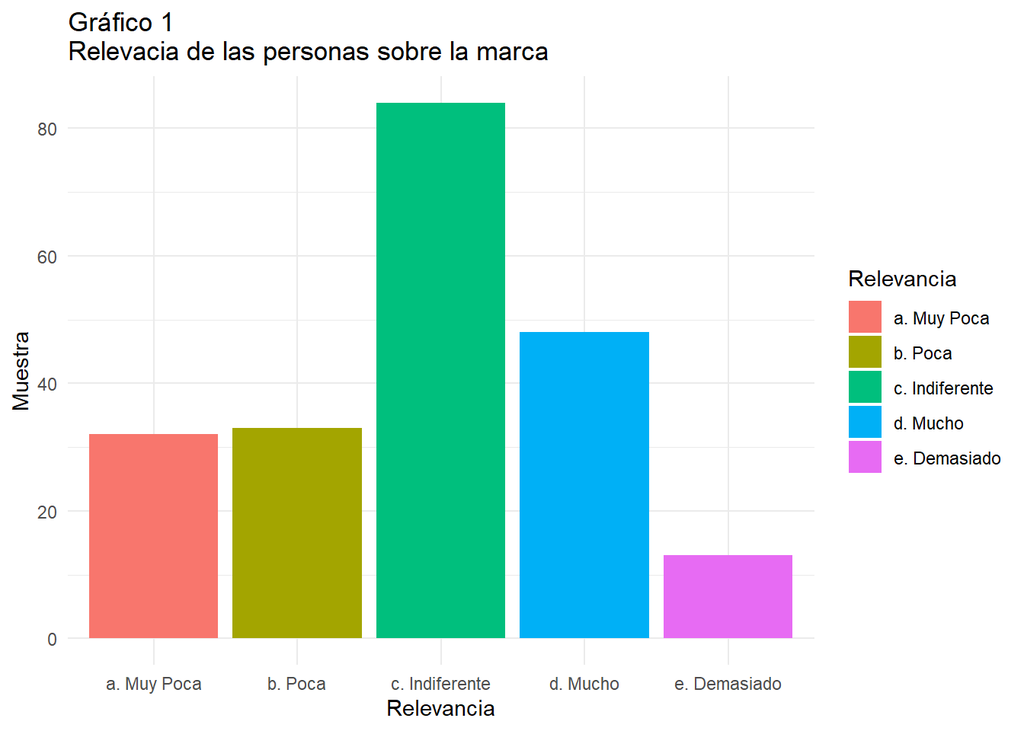

```r
r1<-table(D$Marca[D$R_marca==1])
r2<-table(D$Marca[D$R_marca==2])
r3<-table(D$Marca[D$R_marca==3])
r4<-table(D$Marca[D$R_marca==4])
r5<-table(D$Marca[D$R_marca==5])
Muestra<-c(sum(r1), sum(r2), sum(r3), sum(r4), sum(r5))
Relevancia<-c("a. Muy Poca","b. Poca","c. Indiferente","d. Mucho","e. Demasiado")
M<-data.frame()
ggplot(M,aes(x=Relevancia, y=Muestra, fill=Relevancia))+ geom_bar(position = "dodge", stat = "identity")+ theme_minimal()+ggtitle("Gráfico 1\nRelevacia de las personas sobre la marca")
```

Primero, muestra la cantidad de personas que marcaron cada nivel de relevancia respecto a la marca del detergente: Después de la recuperación de datos se puede concluir que el (40%) de las muestras se encuentran indiferentes a la marca que adquieren.

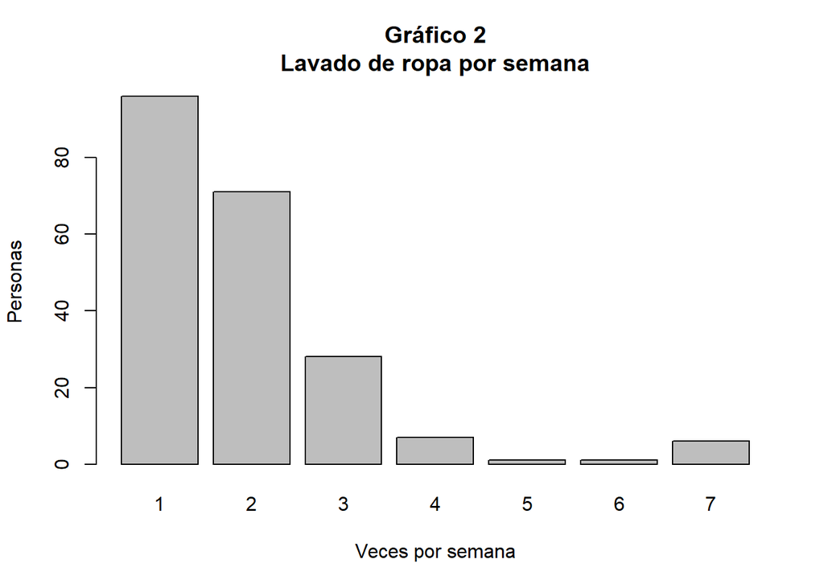

```r
l<-table(D$F_lavado)
barplot(l, xlab = "Veces por semana", ylab = "Personas", main = "Gráfico 2\nLavado de ropa por semana")
```

```r
cat('Media:', mean(l),'\n')
```

```
## Media: 30
```

```r
cat('Coeficiente de Variación:', sd(l)/mean(l)*100,'\n')
```

```
## Coeficiente de Variación: 127.8599
```

El grafico 2, de veces de lavado de ropa por semana, indica el número de individuos que lavan distintos días a la semana. El (45.7%) de los encuestados lava 1 vez por semana, (33.8%) 2 veces por semana, (13.3%) 3 veces por semana, (3.34%) 4 veces por semana, (0.5%) 5 veces por semana, (0.5%) veces por semana y (2.9%) lava su ropa diariamente.

Se puede concluir que la moda para esta variable es 1, es decir que la mayoria de personas lava su ropa 1 vez por semana.

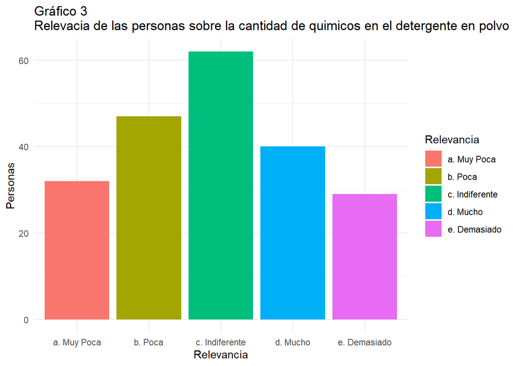

```r
r1<-table(D$Marca[D$C_quimicos==1])
r2<-table(D$Marca[D$C_quimicos==2])
r3<-table(D$Marca[D$C_quimicos==3])
r4<-table(D$Marca[D$C_quimicos==4])
r5<-table(D$Marca[D$C_quimicos==5])
Personas<-c(sum(r1), sum(r2), sum(r3), sum(r4), sum(r5))
Relevancia<-c("a. Muy Poca","b. Poca","c. Indiferente","d. Mucho","e. Demasiado")
M<-data.frame()
ggplot(M,aes(x=Relevancia, y=Personas, fill=Relevancia))+ geom_bar(position = "dodge", stat = "identity")+ theme_minimal()+ggtitle("Gráfico 3\nRelevacia de las personas sobre la cantidad de quimicos en el detergente en polvo")
```

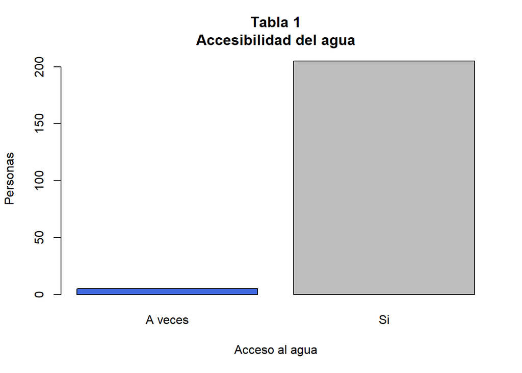

```r
D2<-table(D$Dispo_agua)

barplot(D2,  main = "Tabla 1\nAccesibilidad del agua",
     xlab = "Acceso al agua", ylab = "Personas",
     col = c("royalblue", "grey"))
```

La gran mayoria de personas entrevistadas cuentan con acceso al agua, lo cual les permite lavar su ropa de manera efectiva.

##PROBABILIDADES

¿Cuanto es el precio máximo que un joven esta dispuesto a pagar por el detergente?

El precio máximo es un factor importante para un consumidor joven. Como se sabe, los jóvenes estudiantes no cuentan con ingresos fijos y siempre buscan ahorrar costos. Para validar esto veremos la edad de nuestros entrevistados y la dispersión

```r
edadEntrevistados <- mean(D$Edad)
edadEntrevistados
```

```
## [1] 22.4381
```

```r
sd(D$Edad)
```

```
## [1] 7.990932
```

El promedio de la edad de los entrevistados es de $22.43$ y con desviacion estandar de $7.9$. Como veremos la desviacion estandar esta un poco alta. Veremos si existen datos atípicos que podamos sacar.

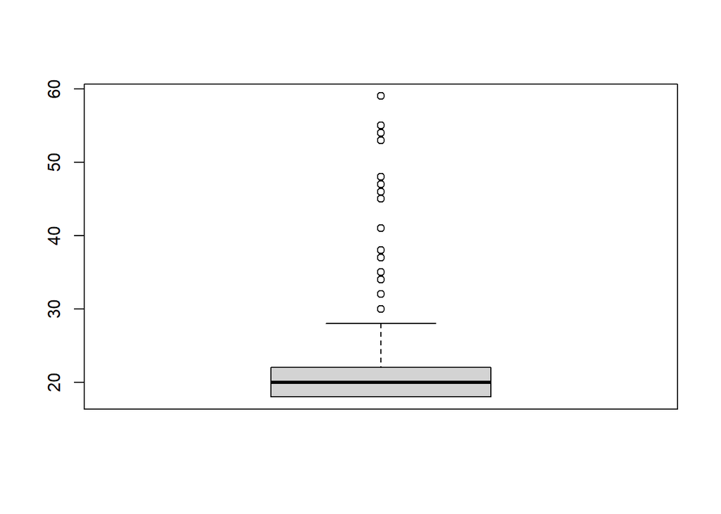

```r
Edad<-(D$Edad)
boxplot(Edad)
```

Como podemos ver, la edad de los entrevistados no es uniforme. Existen varios datos atipicos que pueden hacer que la media se vea segada. Lo siguiente que haremos sera mostrar los descriptores numericos de la variable edad sin los datos atípicos.

```r
#Quitando datos atipicos
edadLimpia<- D$Edad[!D$Edad %in% boxplot.stats(D$Edad)$out]
sd(edadLimpia)
```

```
## [1] 2.264495
```

```r
mean(edadLimpia)
```

```
## [1] 19.91979
```

Como se puede ver, ahora la media de la edad es menor $19.91$ y nosotros creemos que es mas representativa ya que para este caso en particular estamos explorando a compradores jovenes.

Se sabe que en el precio hay un outlier el cual se reemplazara por un valor dentro del rango esperado para propositos del modelo.

```r
which.max(D$P_maximo)
```

```
## [1] 175
```

```r
D$P_maximo[175] <- 11
```

Una vez que se tiene valores razonables para el precio maximo que los encuestados estarian dispuestos a pagar, se busca la correlacion entre la variable precio maximo y edad del ecuestado.

```r
cor(D$P_maximo,D$Edad)
```

```
## [1] 0.08227472
```

La correlacion entre el precio maximo que esta dispuesto a pagar el encuestado y su edad es positiva, sin embargo, no es fuerte. Esto significa que no estan significativamente relacionadas las variables, el valor de la correlacion es $0.08$.

Aun así se hace el diagrama de dispersion para ver si exite alguna tendencia al precio masimo a pagar por la edad del encuestado.

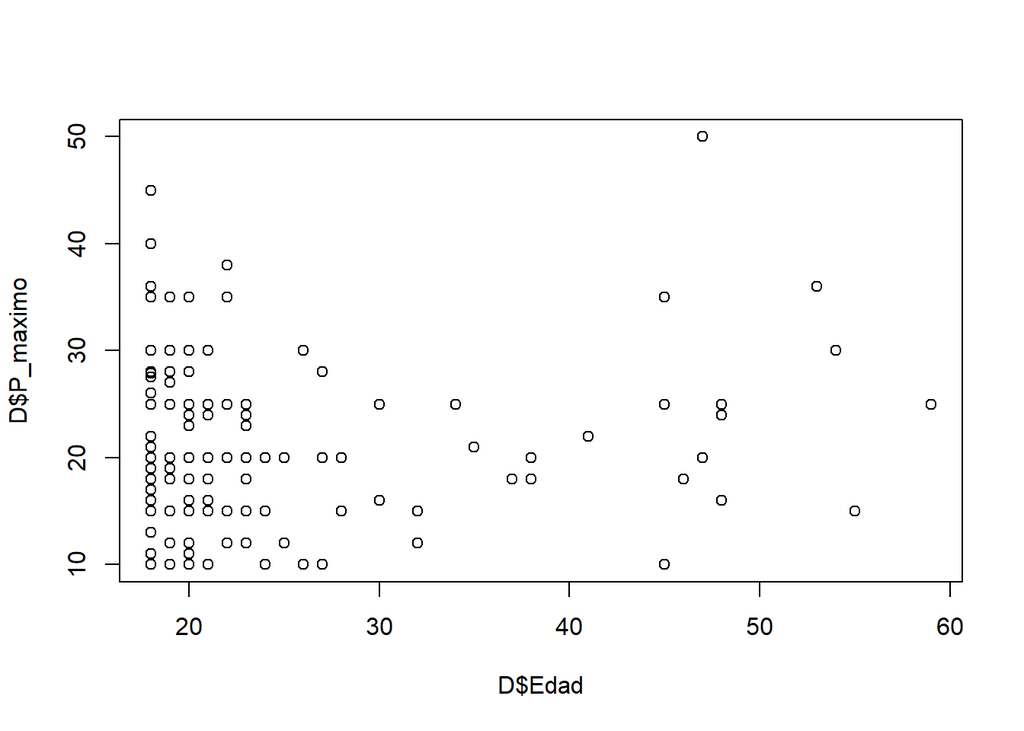

```r
#Diagrama de dispersion para saber si existe una tendencia aparente

plot(D$P_maximo~D$Edad)
```

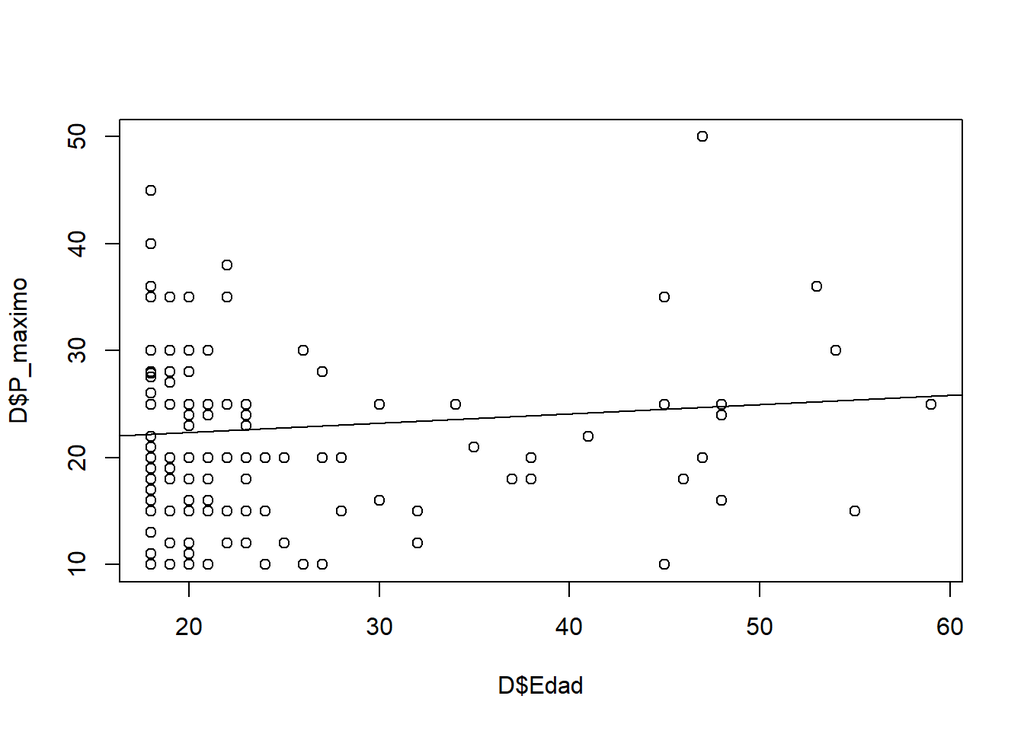

```r
plot(D$P_maximo~D$Edad)
abline(lm(D$Edad~D$P_maximo))
```

```r
modelo <- lm(D$P_maximo~D$Edad)
summary(modelo)
```

```
##
## Call:
## lm(formula = D$P_maximo ~ D$Edad)
##
## Residuals:
##      Min       1Q   Median       3Q      Max
## -12.3028  -5.3495  -0.3886   4.8068  27.5409
##
## Coefficients:
##             Estimate Std. Error t value Pr(>|t|)
## (Intercept) 18.78688    1.56262  12.023   <2e-16 ***
## D$Edad       0.07813    0.06562   1.191    0.235
## ---
## Signif. codes:  0 '***' 0.001 '**' 0.01 '*' 0.05 '.' 0.1 ' ' 1
##
## Residual standard error: 7.581 on 208 degrees of freedom
## Multiple R-squared:  0.006769,   Adjusted R-squared:  0.001994
## F-statistic: 1.418 on 1 and 208 DF,  p-value: 0.2352
```

##Analisis probabilistico de la variable Frecuencia de Lavado

Se instala el paquete “Fitdistrplus” para poder realizar el analisis probabilistico de la variable frecuencia de lavado.

Se procede a hacer un histograma de la variable frecuencia de lavado y un grafico de Cullen y Frey que ayuda a ver a que tipo de distribuciones los valores de frecuencia de lavado le corresponden. boot= simula otras distribuciones parecidas, cantidad de simulaciones

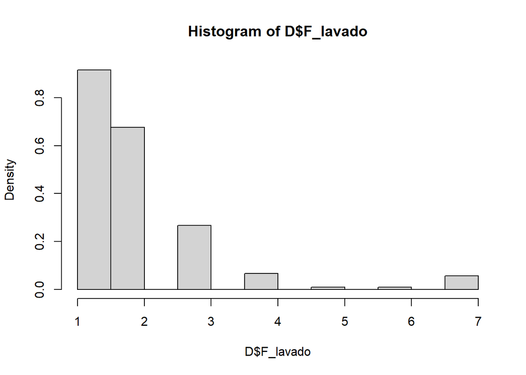

```r
hist(D$F_lavado, probability=TRUE)
```

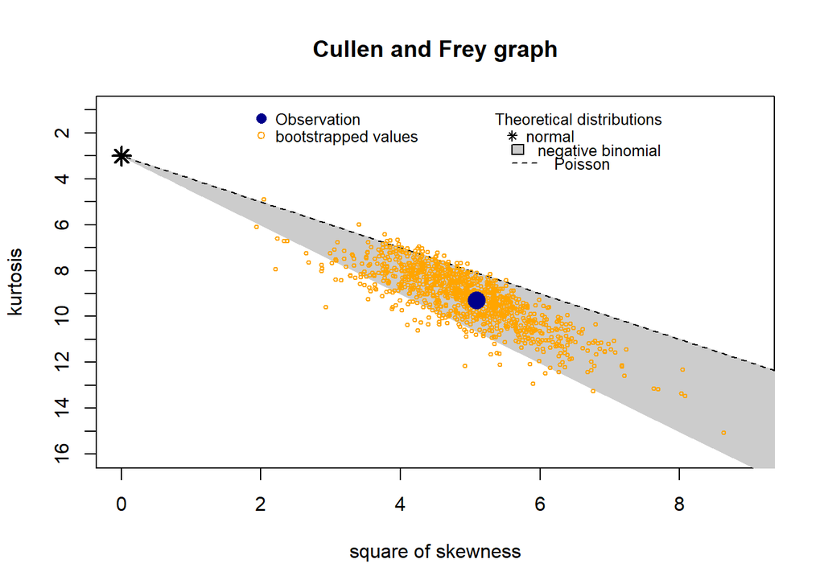

```
## summary statistics
## ------
## min:  1   max:  7
## median:  2
## mean:  1.919048
## estimated sd:  1.248202
## estimated skewness:  2.255965
## estimated kurtosis:  9.296362
```

```r
library(fitdistrplus)
descdist(D$F_lavado, discrete = TRUE, boot = 1000)
```

Podemos observar en el grafico Cullen and Frey que nuestra ditribución se puede modelar como una distribucion binomial negativa o como una Poisson. En este caso modelaremos nuestra variable con una distribucion poisson debido a que teoricamente la variable poisson modela la cantidad de eventos en un intervalo de tiempo y nuestra variable F_Lavado representa la cantidad de veces que una persona lava en una semana.

Al creer que los datos de frecuencia de lavado tienen una distribucion Poisson buscamos el lambda para poder trabajar con sus proabilidades.

```r
fitdist(D$F_lavado, "pois")
```

```
## Fitting of the distribution ' pois ' by maximum likelihood
## Parameters:
##        estimate Std. Error
## lambda 1.919048 0.09559455
```

El lambda vendría a ser $1.91$. A partir de este dato buscaremos distintas probabilidades relacionadas a la frecuencia de lavado de los encuestados.

¿Cual es la probabilidad de que una persona al azar lave su ropa 2 veces por semana?

```r
dpois(2,1.91)
```

```
## [1] 0.270106
```

##Analisis probabilistico de Precio

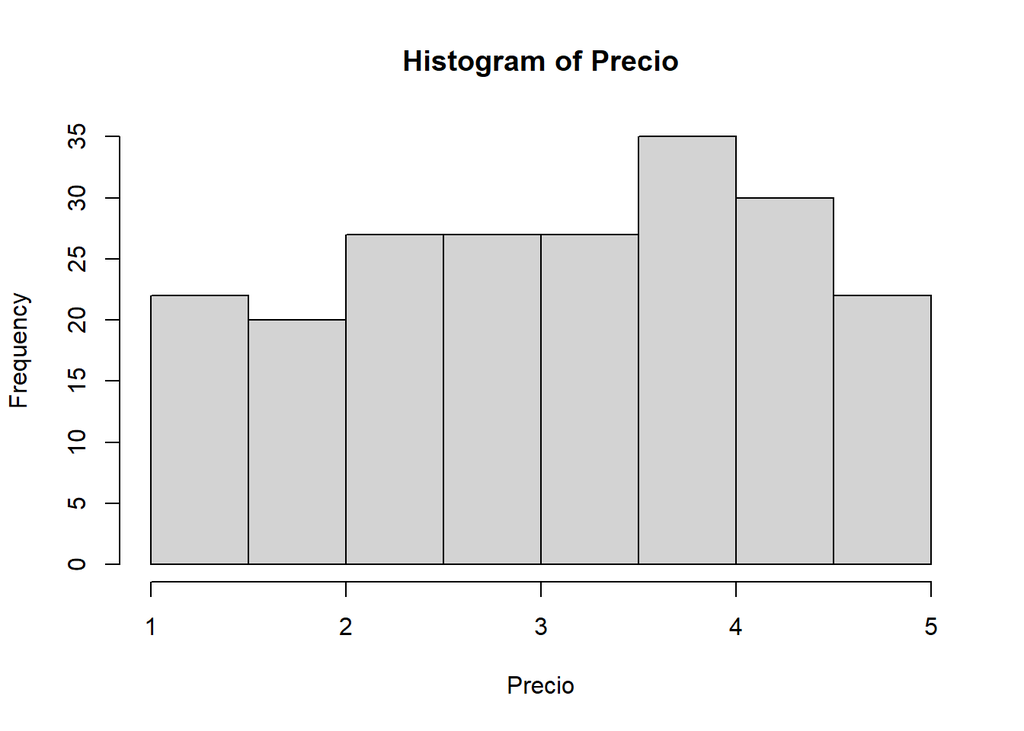

```r
Precio<-(D$Precio)
hist(Precio)
```

Como podemos ver, la variable importancia a precio se asemeja e a una distribucion uniforme. Esto quiere decir que la probabilidad de que a una persona le importe el precio es igualmente probable para cada nivel de importancia.

Esto se confirmara con un grafico de Cullen and Frey.

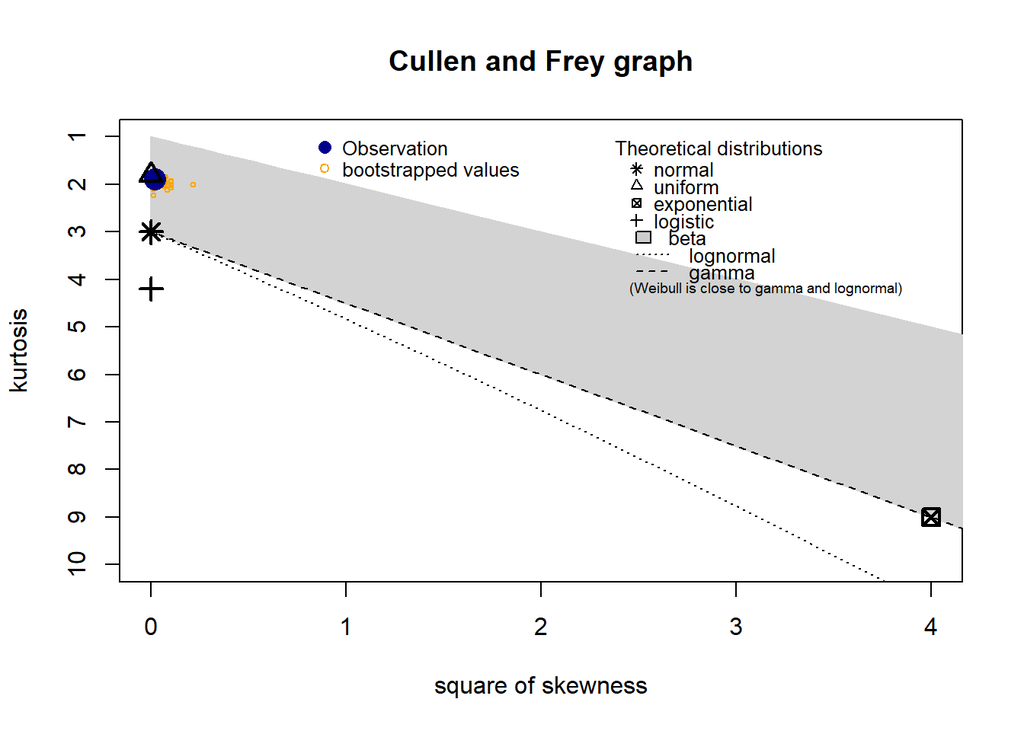

```
## summary statistics
## ------
## min:  1   max:  5
## median:  3.2
## mean:  3.148571
## estimated sd:  1.101379
## estimated skewness:  -0.1373706
## estimated kurtosis:  1.882711
```

```r
descdist(D$Precio, boot= 100)
```

```r
fitdist(D$Precio, "unif")
```

```
## Fitting of the distribution ' unif ' by maximum likelihood
## Parameters:
##     estimate Std. Error
## min        1         NA
## max        5         NA
```

¿Cual es la probabilidad de que una persona escogida al azar le importe el precio en hasta 2 puntos?

Se define como puntos en la encuesta a la pregunta de ¿Que tanto importa el precio para tí? Siendo el valor 1 como menos me importa y el valor 5 como mas me importa.

```r
punif(2,max = 5,min=1)
```

```
## [1] 0.25
```

##Distribucion de Bernoulli

Vamos a modelar la variable Compra por costumbre. Esta variable responde la pregunta ¿Eliges tu detergente por costumbre?. Si la respuesta es si quiere decir que la persona no toma en referencia otros factores como lo impreso en el empaque o las propiedades del producto. Esta variable es relevante por que nos indica la probabilidad de que una persona elija un detergente solo por que es el detergente de siempre. Podemos decir que mientras mayor sea la probabilidad de que una persona elija un detergente por costumbre entonces la probabilidad de comprar una nueva marca puede disminuir.

A continuación vemos el histograma.

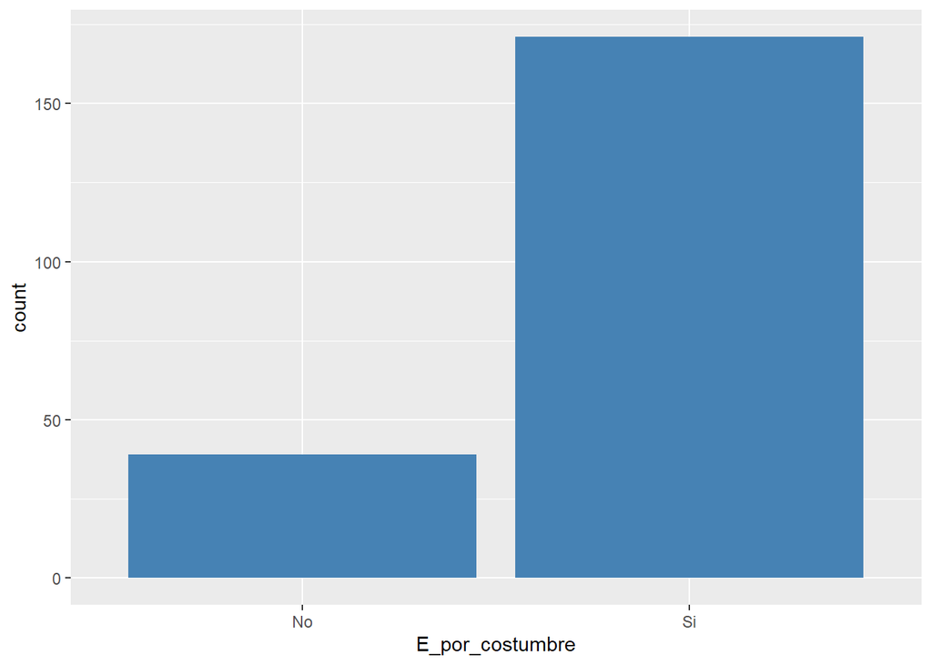

```r
ggplot(D) +
  aes(x = E_por_costumbre) +
  geom_bar(fill = "#4682B4") +
  theme_gray()
```

Usaremos las probabilidades relacionadas a cada opción usando una tabla de frecuencia.

```r
valor1 <- table(D$E_por_costumbre)
round(valor1/nrow(D),2)
```

```
##
##   No   Si
## 0.19 0.81
```

Usando estas probabilidades y asumiendo que cada persona tiene una opinion independiente nos hacemos las siguientes preguntas.

Definimos el éxito como 1 <- La persona compra por costumbre con probabilidad $0.81$

Si escojo 20 personas al azar,¿Cual es la probabilidad de que menos o 10 personas respondan que compran su detergente por costumbre?

```r
pbinom(10,20,0.81)
```

```
## [1] 0.001730917
```

[output not shown]

[output not shown]

[output not shown]

[output not shown]

[output not shown]

[output not shown]

[output not shown]

[output not shown]

[output not shown]

[output not shown]

[output not shown]

[output not shown]

[output not shown]

[output not shown]

[output not shown]

[output not shown]

[output not shown]

[output not shown]

[output not shown]

[output not shown]

[output not shown]

[output not shown]

[output not shown]

[output not shown]

[output not shown]

```r
tabla<-data.frame(
  "X"=c("[0;15>", "[15;20>", "[20;25>", "[25;30>", "[30;∞>"),
  "Muy Poca"=c(M11,M12,M13,M14,M15),
  "Poca"=c(M21,M22,M23,M24,M25),
  "Indiferente"=c(M31,M32,M33,M34,M35),
  "Mucho"=c(M41,M42,M43,M44,M45),
  "Demasiado"=c(M51,M52,M53,M54,M55)
)
```

```r
tabla
```

```
##         X Muy.Poca Poca Indiferente Mucho Demasiado
## 1  [0;15>        6    9           6     8         3
## 2 [15;20>        5    9           9     4         6
## 3 [20;25>       13   20          23    17        11
## 4 [25;30>        8   14          10     7         9
## 5  [30;8>        3    4           1     0         5
```

```r
dhyper(5, 6, 210-6, 80)
```

```
## [1] 0.02819618
```

```r
phyper(20,27,210-27,100)
```

```
## [1] 0.999323
```

Del caso anterior, ¿cual seria la probabilidad de que sean mas de 20 personas? P(x>20)

```r
1-phyper(20,27,210-27,100)
```

```
## [1] 0.0006770377
```

[output not shown]

[output not shown]

[output not shown]

[output not shown]

[output not shown]

[output not shown]

[output not shown]

[output not shown]

[output not shown]

[output not shown]

[output not shown]

[output not shown]

[output not shown]

[output not shown]

[output not shown]

[output not shown]

[output not shown]

[output not shown]

[output not shown]

[output not shown]

[output not shown]

[output not shown]

[output not shown]

[output not shown]

[output not shown]

[output not shown]

[output not shown]

[output not shown]

[output not shown]

[output not shown]

[output not shown]

[output not shown]

[output not shown]

[output not shown]

[output not shown]

[output not shown]

[output not shown]

[output not shown]

[output not shown]

[output not shown]

[output not shown]

[output not shown]

[output not shown]

[output not shown]

[output not shown]

[output not shown]

[output not shown]

[output not shown]

[output not shown]

[output not shown]

[output not shown]

[output not shown]

[output not shown]

[output not shown]

[output not shown]

[output not shown]

[output not shown]

[output not shown]

[output not shown]

[output not shown]

[output not shown]

[output not shown]

[output not shown]

```r
tabla
```

```
##           X X1.vez.a.la.semana X2.veces.a.la.semana X3.veces.a.la.semana
## 1       Ace                 20                   14                    3
## 2    Patito                  4                    4                    0
## 3   Bolivar                 31                   21                   13
## 4  Marsella                 12                   12                    6
## 5   Sapolio                  4                    3                    0
## 6     Ariel                 19                   11                    5
## 7    Boreal                  1                    2                    0
## 8      Opal                  2                    2                    1
## 9    Biobel                  0                    1                    0
## 10                          93                   70                   28
##    X4.veces.a.la.semana X5.veces.a.la.semana X6.veces.a.la.semana
## 1                     0                    1                    0
## 2                     2                    0                    0
## 3                     1                    0                    0
```

[output cut: 18 more lines]

De los resultados de la encuesta, se toma una muestra considerando las 9 marcas mas populares usadas en este estudio y comparandolo con las veces que lavan la ropa durante la semana, resultando en una muestra de 206 personas. Si sabemos que el 15.12% de los encuestados prefiere la marca Bolivar y que solo lavas la ropa 1 vez por semana, al extraer a 8 personas de la muestra con reemplazo ¿Cual es la probabilidad de que solo 6 personas de la extraccion prefieran Bolivar y que tambien solo laven una vez por semana? X:numero de encuestados que prefiern Bolivar y solo lavan 1 vez por semana X tiene B(x=6, n=8, p=0.1512) P(X=6)

**La respuesta es igual a:** 0.0002410347

```r
dbinom(6,8,0.1512)
```

```
## [1] 0.0002410347
```

¿Que sean menor o igual a 4 la cantidad de personas? P(X≤4) X tiene B(x=4, n=8, p=0.1512)

**La respuesta es igual a:** 0.9970402

```r
pbinom(4,8,0.1512)
```

```
## [1] 0.9970402
```

```r
1-pbinom(1,8,0.1512)
```

```
## [1] 0.3466177
```